# Assignment 1:

**Import libraries and read in csv file:**

```python
import numpy as np
import pandas as pd
import matplotlib.pyplot as plt
%cd "/Users/jonathanlynch/Desktop/DSC 478"

data = pd.read_csv("bank_data.csv", index_col=0)
data.head(10)
```

```
/Users/jonathanlynch/Desktop/DSC 478
```

| id | age | income | children | gender | region | married | car | savings_acct | current_acct | mortgage | pep |
| --- | --- | --- | --- | --- | --- | --- | --- | --- | --- | --- | --- |
| ID12101 | 48 | 17546.00 | 1 | FEMALE | INNER_CITY | NO | NO | NO | NO | NO | YES |
| ID12102 | 40 | 30085.10 | 3 | MALE | TOWN | YES | YES | NO | YES | YES | NO |
| ID12103 | 51 | 16575.40 | 0 | FEMALE | INNER_CITY | YES | YES | YES | YES | NO | NO |
| ID12104 | 23 | 20375.40 | 3 | FEMALE | TOWN | YES | NO | NO | YES | NO | NO |
| ID12105 | 57 | 50576.30 | 0 | FEMALE | RURAL | YES | NO | YES | NO | NO | NO |
| ID12106 | 57 | 37869.60 | 2 | FEMALE | TOWN | YES | NO | YES | YES | NO | YES |
| ID12107 | 22 | 8877.07 | 0 | MALE | RURAL | NO | NO | NO | YES | NO | YES |
| ID12108 | 58 | 24946.60 | 0 | MALE | TOWN | YES | YES | YES | YES | NO | NO |
| ID12109 | 37 | 25304.30 | 2 | FEMALE | SUBURBAN | YES | YES | NO | NO | NO | NO |
| ID12110 | 54 | 24212.10 | 2 | MALE | TOWN | YES | YES | YES | YES | NO | NO |

## Part 1:

**Examine the descriptive statistics of the numerical variables:**

```python
print("Age stats:\n")
print(data["age"].describe())
print()
print("Income stats:\n")
print(data["income"].describe())
print()
print("Children stats:\n")
print(data["children"].describe())
```

```
Age stats:

count    600.000000
mean      42.395000
std       14.424947
min       18.000000
25%       30.000000
50%       42.000000
75%       55.250000
max       67.000000
Name: age, dtype: float64

Income stats:

count      600.000000
mean     27524.031217
std      12899.468246
min       5014.210000
25%      17264.500000
50%      24925.300000
75%      36172.675000
max      63130.100000
Name: income, dtype: float64

Children stats:

count    600.000000
mean       1.011667
std        1.056752
min        0.000000
25%        0.000000
50%        1.000000
75%        2.000000
max        3.000000
Name: children, dtype: float64
```

By looking at the descriptive statistics of the age variable, we can see the mean (42.395 years) and median (42 years) ages. The minimum age is 18 years, and the maximum age is 67 years. The first quartile (Q1/25th percentile) is located at 30 years, and the third quartile (Q3/75th percentile) is 55.25 years. This means that roughly 50% of the ages fall between 30 years and 55.25 years. The standard deviation is approximately 14.42 years.

By looking at the descriptive statistics of the income variable, we can see the mean (27,524.03) and median (24,925.30) incomes. The minimum income is 5,014.21, and the maximum income is 63,130.10. The first quartile (Q1/25th percentile) is located at 17,264.50, and the third quartile (Q3/75th percentile) is 36,172.675. This means that roughly 50% of the incomes fall between 17,264.50 and 36,172.675. The standard deviation is approximately 12,899.47.

By looking at the descriptive statistics of the children variable, we can see the mean (1.0117) and median (1.0) number of children for each customer. The minimum number of children is 0, and the maximum number of children is 3. The first quartile (Q1/25th percentile) is located at 0 children, and the third quartile (Q3/75th percentile) is 2 children. This means that roughly 50% of the customers have a number of children that falls between 0 and 2 kids. The standard deviation is approximately 1.057 children.

**Look at the distributions of the categorical variables:**

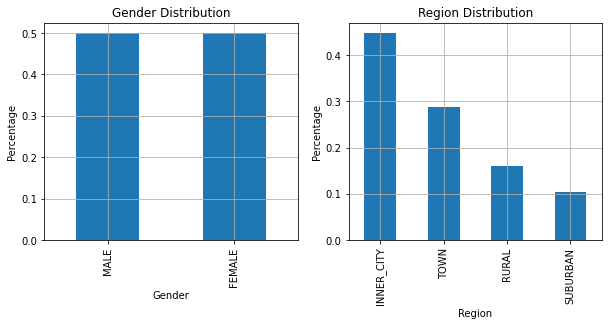

```python
temp1 = data["gender"].value_counts()/data["gender"].count()
temp2 = data["region"].value_counts()/data["region"].count()

fig = plt.figure(figsize=(10,4))
ax1 = fig.add_subplot(121)
ax1.set_xlabel('Gender')
ax1.set_ylabel('Percentage')
ax1.set_title("Gender Distribution")
temp1.plot(kind='bar', grid = True)

ax1 = fig.add_subplot(122)
ax1.set_xlabel('Region')
ax1.set_ylabel('Percentage')
ax1.set_title("Region Distribution")
temp2.plot(kind='bar', grid = True)
```

The above histogram of the categorical variable gender shows the distribution percentage of male and female customers. From this graph, we can see that this bank’s customers appear to be evenly divided along gender (50% male and 50% female).

The above histogram of the categorical variable region shows the distribution percentage of the regions where customers live. From this graph, we can see that the majority of customers live in the inner city (> 45% of customers). The region with the second highest percentage of customers is towns (almost 30% of customers). The two regions with the fewest customers are rural (~ 15% of customers) and suburban (~ 10% of customers).

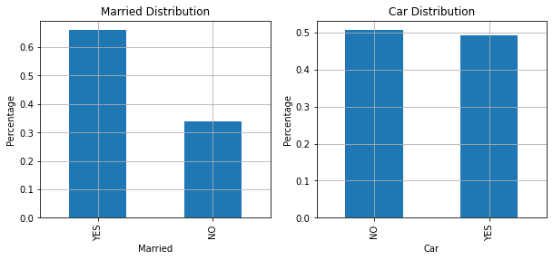

```python
temp1 = data["married"].value_counts()/data["married"].count()
temp2 = data["car"].value_counts()/data["car"].count()

fig = plt.figure(figsize=(10,4))
ax1 = fig.add_subplot(121)
ax1.set_xlabel('Married')
ax1.set_ylabel('Percentage')
ax1.set_title("Married Distribution")
temp1.plot(kind='bar', grid = True)

ax1 = fig.add_subplot(122)
ax1.set_xlabel('Car')
ax1.set_ylabel('Percentage')
ax1.set_title("Car Distribution")
temp2.plot(kind='bar', grid = True)
```

The above histogram of the categorical variable married shows the distribution percentage of customers who are married and those who are not married. From this graph, we can see that the majority of customers are married (~ 65% of customers), and fewer customers are unmarried (~ 35% of customers).

The above histogram of the categorical variable car shows the distribution percentage of customers who own at least one car and those who do not. From this graph, we can see this attribute is pretty evenly divided. A little less than 50% of the customers own at least one vehicle, and just over 50% of the customers do not own a car.

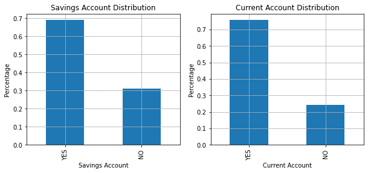

```python
temp1 = data["savings_acct"].value_counts()/data["savings_acct"].count()
temp2 = data["current_acct"].value_counts()/data["current_acct"].count()

fig = plt.figure(figsize=(10,4))
ax1 = fig.add_subplot(121)
ax1.set_xlabel('Savings Account')
ax1.set_ylabel('Percentage')
ax1.set_title("Savings Account Distribution")
temp1.plot(kind='bar', grid = True)

ax1 = fig.add_subplot(122)
ax1.set_xlabel('Current Account')
ax1.set_ylabel('Percentage')
ax1.set_title("Current Account Distribution")
temp2.plot(kind='bar', grid = True)
```

The above histogram of the categorical variable savings account shows the distribution percentage of customers who have a savings account and those who do not. From this graph, we can see that the majority of customers (~ 70%) have a savings account, and fewer customers (~ 30%) do not.

The above histogram of the categorical variable current account shows the distribution percentage of customers who have a checking account and those who do not. From this graph, we can see that the majority of customers (~ 75%) have a checking account, and fewer customers (~ 25%) do not.

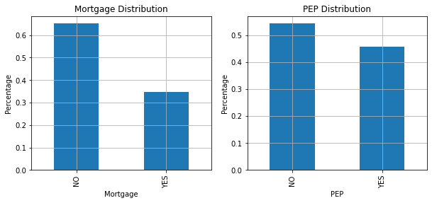

```python
temp1 = data["mortgage"].value_counts()/data["mortgage"].count()
temp2 = data["pep"].value_counts()/data["pep"].count()

fig = plt.figure(figsize=(10,4))
ax1 = fig.add_subplot(121)
ax1.set_xlabel('Mortgage')
ax1.set_ylabel('Percentage')
ax1.set_title("Mortgage Distribution")
temp1.plot(kind='bar', grid = True)

ax1 = fig.add_subplot(122)
ax1.set_xlabel('PEP')
ax1.set_ylabel('Percentage')
ax1.set_title("PEP Distribution")
temp2.plot(kind='bar', grid = True)
```

The above histogram of the categorical variable mortgage shows the distribution percentage of customers who have a mortgage and those who do not. From this graph, we can see that the majority of customers (~ 65%) do not have a mortgage, and fewer customers (~ 35%) have a mortgage.

The above histogram of the categorical variable pep shows the distribution percentage of customers who purchased a personal equity plan (PEP) and those who did not. From this graph, we can see that the majority of customers (~ 55%) did not purchase a PEP, and fewer customers (~ 45%) did purchase a PEP.

## Part 2:

**Evaluate the descriptive statistics of the numerical variables for customers who purchased a PEP :**

```python
PEP = data[(data.pep == 'YES')]
print("Purchased PEP - Age stats:\n")
print(PEP["age"].describe())
print()
print("Purchased PEP - Income stats:\n")
print(PEP["income"].describe())
print()
print("Purchased PEP - Children stats:\n")
print(PEP["children"].describe())
```

```
Purchased PEP - Age stats:

count    274.000000
mean      45.127737
std       14.327991
min       18.000000
25%       34.000000
50%       45.000000
75%       58.000000
max       67.000000
Name: age, dtype: float64

Purchased PEP - Income stats:

count      274.000000
mean     30644.919453
std      13609.613043
min       7756.360000
25%      19639.475000
50%      28080.050000
75%      38458.350000
max      63130.100000
Name: income, dtype: float64

Purchased PEP - Children stats:

count    274.000000
mean       0.945255
std        0.860571
min        0.000000
25%        0.000000
50%        1.000000
75%        1.000000
max        3.000000
Name: children, dtype: float64
```

By looking at the descriptive statistics of the age variable for customers who purchased a PEP, we can see the mean (45.1277 years) and median (45 years) ages. The minimum age is 18 years, and the maximum age is 67 years. The first quartile (Q1/25th percentile) is located at 34 years, and the third quartile (Q3/75th percentile) is 58 years. This means that roughly 50% of the customers who purchased a PEP fall between the ages of 34 and 58. The standard deviation is approximately 14.33 years.

By looking at the descriptive statistics of the income variable for customers who purchased a PEP, we can see the mean (30,644.9195) and median (28,080.05) incomes. The minimum income is 7,756.36, and the maximum income is 63,130.10. The first quartile (Q1/25th percentile) is located at 19,639.475, and the third quartile (Q3/75th percentile) is 38,458.35. This means that roughly 50% of customers who purchased a PEP had incomes that fell between 19,639.475 and 38,458.35. The standard deviation is approximately 13,609.61.

By looking at the descriptive statistics of the children variable for customers who purchased a PEP, we can see the mean (.9453) and median (1.0) number of children for each customer. The minimum number of children is 0, and the maximum number of children is 3. The first quartile (Q1/25th percentile) is located at 0 children, and the third quartile (Q3/75th percentile) is 1.0 children. This means that roughly 50% of customers who purchased a PEP have a number of children that falls between 0 and 1.0 kids. The standard deviation is approximately 0.86 children.

**Look at the distributions of the categorical variables for customers who purchased a PEP:**

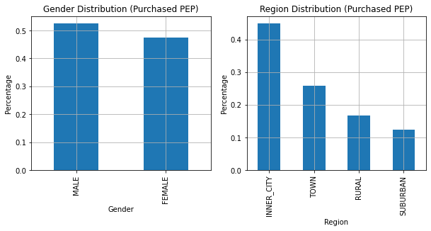

```python
temp1 = PEP["gender"].value_counts()/PEP["gender"].count()
temp2 = PEP["region"].value_counts()/PEP["region"].count()

fig = plt.figure(figsize=(10,4))
ax1 = fig.add_subplot(121)
ax1.set_xlabel('Gender')
ax1.set_ylabel('Percentage')
ax1.set_title("Gender Distribution (Purchased PEP)")
temp1.plot(kind='bar', grid = True)

ax1 = fig.add_subplot(122)
ax1.set_xlabel('Region')
ax1.set_ylabel('Percentage')
ax1.set_title("Region Distribution (Purchased PEP)")
temp2.plot(kind='bar', grid = True)
```

The above histogram of the categorical variable gender for customers who purchased a PEP shows the percentage of customers that purchased a PEP who were male, as well as the percentage of customers that purchased a PEP who were female. From this graph, we can see that a higher percentage of customers who purchased a PEP (~ 53%) were male. A smaller percentage of customers who purchased a PEP (~ 47%) were female.

The above histogram of the categorical variable region for customers who purchased a PEP shows the breakdown by region where each of these customers live. From this graph, we can see that approximately 45% of customers who purchased a PEP live in the inner city, about 26% of customers who purchased a PEP live in towns, around 17% of customers who purchased a PEP live in rural areas, and only about 12% of customers who purchased a PEP live in suburban areas.

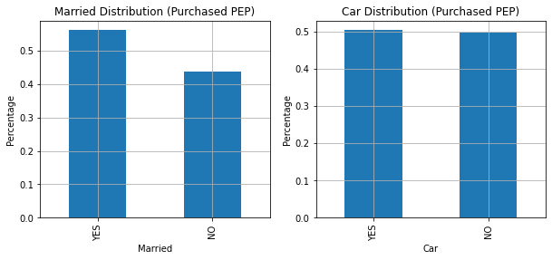

```python
temp1 = PEP["married"].value_counts()/PEP["married"].count()
temp2 = PEP["car"].value_counts()/PEP["car"].count()

fig = plt.figure(figsize=(10,4))
ax1 = fig.add_subplot(121)
ax1.set_xlabel('Married')
ax1.set_ylabel('Percentage')
ax1.set_title("Married Distribution (Purchased PEP)")
temp1.plot(kind='bar', grid = True)

ax1 = fig.add_subplot(122)
ax1.set_xlabel('Car')
ax1.set_ylabel('Percentage')
ax1.set_title("Car Distribution (Purchased PEP)")
temp2.plot(kind='bar', grid = True)
```

The above histogram of the categorical variable married for customers who purchased a PEP shows the percentage of married and unmarried customers who purchased a PEP. From this graph, we can see that approximately 44% of customers who purchased a PEP were unmarried, and around 56% of customers who purchased a PEP were married.

The above histogram of the categorical variable car for customers who purchased a PEP shows the percentage of customers who purchased a PEP that own at least one vehicle, as well as the percentage of customers who purchased a PEP that do not own a vehicle. From this graph, we can see that slightly less than 50% of customers who purchased a PEP do not own a vehicle, and slightly more than 50% of customers who purchased a PEP own at least one vehicle.

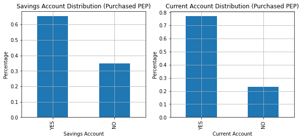

```python
temp1 = PEP["savings_acct"].value_counts()/PEP["savings_acct"].count()
temp2 = PEP["current_acct"].value_counts()/PEP["current_acct"].count()

fig = plt.figure(figsize=(10,4))
ax1 = fig.add_subplot(121)
ax1.set_xlabel('Savings Account')
ax1.set_ylabel('Percentage')
ax1.set_title("Savings Account Distribution (Purchased PEP)")
temp1.plot(kind='bar', grid = True)

ax1 = fig.add_subplot(122)
ax1.set_xlabel('Current Account')
ax1.set_ylabel('Percentage')
ax1.set_title("Current Account Distribution (Purchased PEP)")
temp2.plot(kind='bar', grid = True)
```

The above histogram of the categorical variable savings account for customers who purchased a PEP shows the percentage of customers who purchased a PEP that have a savings account, as well as the percentage of customers who purchased a PEP that do not have a savings account. From this graph, we can see that approximately 35% of customers who purchased a PEP do not have a savings account, and roughly 65% of customers who purchased a PEP have a savings account.

The above histogram of the categorical variable current account for customers who purchased a PEP shows the percentage of customers who purchased a PEP that have a checking account, as well as the percentage of customers who purchased a PEP that do not have a checking account. From this graph, we can see that approximately 23% of customers who purchased a PEP do not have a checking account, and roughly 77% of customers who purchased a PEP have a checking account.

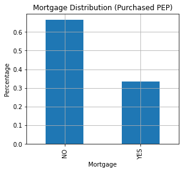

```python
temp = PEP["mortgage"].value_counts()/PEP["mortgage"].count()

fig = plt.figure(figsize=(10,4))
ax1 = fig.add_subplot(121)
ax1.set_xlabel('Mortgage')
ax1.set_ylabel('Percentage')
ax1.set_title("Mortgage Distribution (Purchased PEP)")
temp.plot(kind='bar', grid = True)
```

The above histogram of the categorical variable mortgage for customers who purchased a PEP shows the percentage of customers who purchased a PEP that have a mortgage, as well as the percentage of customers who purchased a PEP that do not have a mortgage. From this graph, we can see that approximately 66% of customers who purchased a PEP do not have a mortgage, and about 34% of customers who purchased a PEP have a mortgage.

**Evaluate the descriptive statistics of the numerical variables for customers who did not purchase a PEP:**

```python
NOPEP = data[(data.pep == 'NO')]
print("No PEP - Age stats:\n")
print(NOPEP["age"].describe())
print()
print("No PEP - Income stats:\n")
print(NOPEP["income"].describe())
print()
print("No PEP - Children stats:\n")
print(NOPEP["children"].describe())
```

```
No PEP - Age stats:

count    326.000000
mean      40.098160
std       14.123506
min       18.000000
25%       27.000000
50%       40.000000
75%       51.000000
max       67.000000
Name: age, dtype: float64

No PEP - Income stats:

count      326.000000
mean     24900.953374
std      11661.123422
min       5014.210000
25%      15366.475000
50%      23105.000000
75%      31210.900000
max      61554.600000
Name: income, dtype: float64

No PEP - Children stats:

count    326.000000
mean       1.067485
std        1.195524
min        0.000000
25%        0.000000
50%        0.000000
75%        2.000000
max        3.000000
Name: children, dtype: float64
```

By looking at the descriptive statistics of the age variable for customers who did not purchase a PEP, we can see the mean (40.0982 years) and median (40 years) ages. The minimum age is 18 years, and the maximum age is 67 years. The first quartile (Q1/25th percentile) is located at 27 years, and the third quartile (Q3/75th percentile) is 51 years. This means that roughly 50% of the ages for customers who did not purchase a PEP fall between 27 years and 51 years. The standard deviation is approximately 14.12 years.

By looking at the descriptive statistics of the income variable for customers who did not purchase a PEP, we can see the mean (24,900.9534) and median (23,105) incomes. The minimum income is 5,014.21, and the maximum income is 61,554.60. The first quartile (Q1/25th percentile) is located at 15,366.475, and the third quartile (Q3/75th percentile) is 31,210.90. This means that roughly 50% of the incomes for customers who did not purchase a PEP fell between 15,366.475 and 31,210.90. The standard deviation is approximately 11,661.12.

By looking at the descriptive statistics of the children variable for customers who did not purchase a PEP, we can see the mean (1.067) and median (0) number of children for each customer. The minimum number of children is 0, and the maximum number of children is 3. The first quartile (Q1/25th percentile) is located at 0 children, and the third quartile (Q3/75th percentile) is 2 children. This means that roughly 50% of customers who did not purchase a PEP have a number of children that falls between 0 and 2 kids. The standard deviation is approximately 1.2 children.

**Look at the distributions of the categorical variables for customers who did not purchase a PEP:**

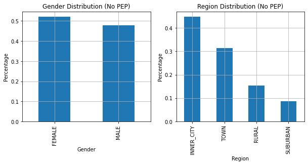

```python
temp1 = NOPEP["gender"].value_counts()/NOPEP["gender"].count()
temp2 = NOPEP["region"].value_counts()/NOPEP["region"].count()

fig = plt.figure(figsize=(10,4))
ax1 = fig.add_subplot(121)
ax1.set_xlabel('Gender')
ax1.set_ylabel('Percentage')
ax1.set_title("Gender Distribution (No PEP)")
temp1.plot(kind='bar', grid = True)

ax1 = fig.add_subplot(122)
ax1.set_xlabel('Region')
ax1.set_ylabel('Percentage')
ax1.set_title("Region Distribution (No PEP)")
temp2.plot(kind='bar', grid = True)
```

The above histogram of the categorical variable gender for customers who did not purchase a PEP shows the percentage of customers that did not purchase a PEP who were male, as well as the percentage of customers that did not purchase a PEP who were female. From this graph, we can see that of the customers who did not purchase a PEP, approximately 52% were female and around 48% were male.

The above histogram of the categorical variable region for customers who did not purchase a PEP shows the breakdown by region where each of these customers live. From this graph, we can see that approximately 45% of customers who did not purchase a PEP live in the inner city, around 31% of customers who did not purchase a PEP live in towns, about 15% of customers who did not purchase a PEP live in rural areas, and nearly 9% of customers who did not purchase a PEP live in suburban areas.

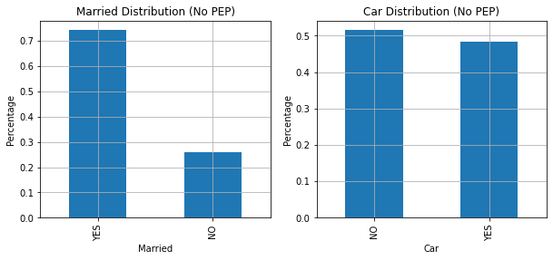

```python
temp1 = NOPEP["married"].value_counts()/NOPEP["married"].count()
temp2 = NOPEP["car"].value_counts()/NOPEP["car"].count()

fig = plt.figure(figsize=(10,4))
ax1 = fig.add_subplot(121)
ax1.set_xlabel('Married')
ax1.set_ylabel('Percentage')
ax1.set_title("Married Distribution (No PEP)")
temp1.plot(kind='bar', grid = True)

ax1 = fig.add_subplot(122)
ax1.set_xlabel('Car')
ax1.set_ylabel('Percentage')
ax1.set_title("Car Distribution (No PEP)")
temp2.plot(kind='bar', grid = True)
```

The above histogram of the categorical variable married for customers who did not purchase a PEP shows the percentage of married and unmarried customers who did not purchase a PEP. From this graph, we can see that approximately 26% of customers who did not purchase a PEP were unmarried, and roughly 74% of customers who did not purchase a PEP were married.

The above histogram of the categorical variable car for customers who did not purchase a PEP shows the percentage of customers who did not purchase a PEP that own at least one vehicle, as well as the percentage of customers who did not purchase a PEP that do not own a vehicle. From this graph, we can see that approximately 52% of customers who did not purchase a PEP do not own a vehicle, and roughly 48% of customers who did not purchase a PEP own at least one vehicle.

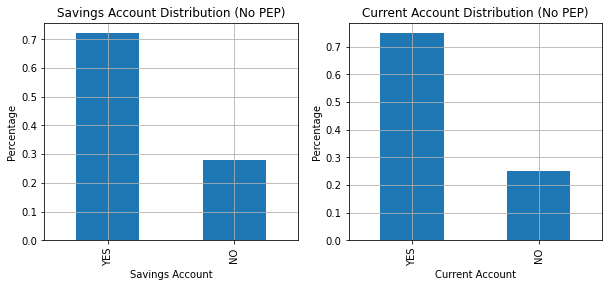

```python
temp1 = NOPEP["savings_acct"].value_counts()/NOPEP["savings_acct"].count()
temp2 = NOPEP["current_acct"].value_counts()/NOPEP["current_acct"].count()

fig = plt.figure(figsize=(10,4))
ax1 = fig.add_subplot(121)
ax1.set_xlabel('Savings Account')
ax1.set_ylabel('Percentage')
ax1.set_title("Savings Account Distribution (No PEP)")
temp1.plot(kind='bar', grid = True)

ax1 = fig.add_subplot(122)
ax1.set_xlabel('Current Account')
ax1.set_ylabel('Percentage')
ax1.set_title("Current Account Distribution (No PEP)")
temp2.plot(kind='bar', grid = True)
```

The above histogram of the categorical variable savings account for customers who did not purchase a PEP shows the percentage of customers who did not purchase a PEP that have a savings account, as well as the percentage of customers who did not purchase a PEP that do not have a savings account. From this graph, we can see that approximately 28% of customers who did not purchase a PEP do not have a savings account, and roughly 72% of customers who did not purchase a PEP have a savings account.

The above histogram of the categorical variable current account for customers who did not purchase a PEP shows the percentage of customers who did not purchase a PEP that have a checking account, as well as the percentage of customers who did not purchase a PEP that do not have a checking account. From this graph, we can see that approximately 25% of customers who did not purchase a PEP do not have a checking account, and roughly 75% of customers who did not purchase a PEP have a checking account.

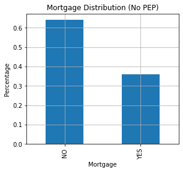

```python
temp = NOPEP["mortgage"].value_counts()/NOPEP["mortgage"].count()

fig = plt.figure(figsize=(10,4))
ax1 = fig.add_subplot(121)
ax1.set_xlabel('Mortgage')
ax1.set_ylabel('Percentage')
ax1.set_title("Mortgage Distribution (No PEP)")
temp.plot(kind='bar', grid = True)
```

The above histogram of the categorical variable mortgage for customers who did not purchase a PEP shows the percentage of customers who did not purchase a PEP that have a mortgage, as well as the percentage of customers who did not purchase a PEP that do not have a mortgage. From this graph, we can see that approximately 64% of customers who did not purchase a PEP do not have a mortgage, and roughly 36% of customers who did not purchase a PEP have a mortgage.

**Conclusions from Part 2:**

Comparing the descriptive statistics of the age variable for the customers who purchased a PEP versus customers who did not purchase a PEP, it is evident that older customers in general tended to be more likely to purchase a PEP. That is, the median age for customers who purchased a PEP was 45 years, while the median age for customers who did not purchase a PEP was only 40 years. Moreover, the interquartile range (IQR) for customers who purchased a PEP was 34-58 years of age, while the interquartile range (IQR) for customers who did not purchase a PEP was 27-51 years of age. As far as income is concerned, customers who purchased a PEP tended to have higher incomes than customers who did not purchase a PEP. The median income for customers who purchased a PEP was 28,080.05, while the median income for customers who did not purchase a PEP was only 23,105. Likewise, the IQR of income for customers who purchased a PEP was 19,639.48 to 38,458.35, and the IQR of income for customers who did not purchase a PEP was only 15,366.48 to 31,210.90. With respect to the number of children, the average number of children for customers who purchased a PEP (.9453) was slightly lower than the average number of children for customers who did not purchase a PEP (1.0675), but not dramatically different.

Since the distribution of the gender variable was evenly divided across the initial set of data (with 50% male customers and 50% female customers), this attribute was relatively easy to interpret. That is, a slightly higher percentage of males purchased a PEP (~ 53%), compared to the percentage of females who purchased a PEP (~ 47%). Customers who live in suburban areas were slightly more likely to purchase a PEP, while customers who live in towns were slightly less likely to purchase a PEP. However, there was not much information to be gained from the other two categories of the region variable; the distribution percentages of customers who live in the inner city or rural regions and either purchased a PEP or did not purchase a PEP aligned very closely with the initial distribution percentages of the complete/full dataset for these two categories of the region variable. As far as the married categorical variable is concerned, unmarried customers tended to be more likely to purchase a PEP compared to married customers. That is, compared to the distribution percentages of unmarried customers (35%) versus married customers (65%) in the initial/complete dataset, a larger percentage of customers who purchased a PEP were unmarried (~ 44%) and a smaller percentage of customers who purchased a PEP were married (~ 56%).

There was not much information to be gained from the car variable, as the distribution percentages of customers who purchased a PEP and customers who did not purchase a PEP closely aligned to that of the distribution percentages of the complete/total dataset (< 2% difference). For the variable savings account, people who did not have a savings account tended to be slightly more likely to purchase a PEP compared to customers who had a savings account. That is, compared to the distribution percentages of customers without a savings account (~ 30%) versus customers with a savings account (~ 70%) in the initial/complete dataset, a slightly larger percentage of customers who purchased a PEP did not have a savings account (~ 35%), and a slightly smaller percentage of customers who purchased a PEP had a savings account (~ 65%). There was not much information to be gained from the variable current account, as the distribution percentages of customers who purchased a PEP and customers who did not purchase a PEP closely aligned to that of the distribution percentages of the complete dataset (< 2% difference). Finally, there was also not much information to be gained from the variable mortgage, as the distribution percentages of the customers who purchased a PEP and customers who did not purchase a PEP closely aligned to that of the distribution percentages of the complete dataset (< 2% difference).

## Part 3:

**Z-score normalization to standardize income values:**

```python
income_z = (data["income"] - data["income"].mean()) / data["income"].std()
income_z.head(5)
```

```
id
ID12101   -0.773523
ID12102    0.198541
ID12103   -0.848766
ID12104   -0.554180
ID12105    1.787071
Name: income, dtype: float64
```

**Add standardized income values into dataframe:**

```python
data["income_z"] = income_z
data.head(5)
```

| id | age | income | children | gender | region | married | car | savings_acct | current_acct | mortgage | pep | income_z |
| --- | --- | --- | --- | --- | --- | --- | --- | --- | --- | --- | --- | --- |
| ID12101 | 48 | 17546.0 | 1 | FEMALE | INNER_CITY | NO | NO | NO | NO | NO | YES | -0.773523 |
| ID12102 | 40 | 30085.1 | 3 | MALE | TOWN | YES | YES | NO | YES | YES | NO | 0.198541 |
| ID12103 | 51 | 16575.4 | 0 | FEMALE | INNER_CITY | YES | YES | YES | YES | NO | NO | -0.848766 |
| ID12104 | 23 | 20375.4 | 3 | FEMALE | TOWN | YES | NO | NO | YES | NO | NO | -0.554180 |
| ID12105 | 57 | 50576.3 | 0 | FEMALE | RURAL | YES | NO | YES | NO | NO | NO | 1.787071 |

## Part 4:

**Discretize age variable into "young", "mid-age", and "old" categories:**

```python
bin_labels = ["young", "mid-age", "old"]

age_bins = pd.qcut(data['age'], q = 3, labels = bin_labels)

age_bins.head(5)
```

```
id
ID12101    mid-age
ID12102    mid-age
ID12103        old
ID12104      young
ID12105        old
Name: age, dtype: category
Categories (3, object): ['young' < 'mid-age' < 'old']
```

**Add discretized age categories into dataframe:**

```python
data["age_disc"] = age_bins
data.head(5)
```

| id | age | income | children | gender | region | married | car | savings_acct | current_acct | mortgage | pep | income_z | age_disc |
| --- | --- | --- | --- | --- | --- | --- | --- | --- | --- | --- | --- | --- | --- |
| ID12101 | 48 | 17546.0 | 1 | FEMALE | INNER_CITY | NO | NO | NO | NO | NO | YES | -0.773523 | mid-age |
| ID12102 | 40 | 30085.1 | 3 | MALE | TOWN | YES | YES | NO | YES | YES | NO | 0.198541 | mid-age |
| ID12103 | 51 | 16575.4 | 0 | FEMALE | INNER_CITY | YES | YES | YES | YES | NO | NO | -0.848766 | old |
| ID12104 | 23 | 20375.4 | 3 | FEMALE | TOWN | YES | NO | NO | YES | NO | NO | -0.554180 | young |
| ID12105 | 57 | 50576.3 | 0 | FEMALE | RURAL | YES | NO | YES | NO | NO | NO | 1.787071 | old |

## Part 5:

**Min-max normalization to standardize age, income & children:**

```python
min_age = data["age"].min()
max_age = data["age"].max()
norm_age = (data["age"] - min_age) / (max_age-min_age)

min_inc = data["income"].min()
max_inc = data["income"].max()
norm_inc = (data["income"] - min_inc) / (max_inc-min_inc)

min_kids = data["children"].min()
max_kids = data["children"].max()
norm_kids = (data["children"] - min_kids) / (max_kids-min_kids)
```

**Replace age, income & children with normalized age, normalized income, & normalized children:**

```python
data["age"] = norm_age

data["income"] = norm_inc

data["children"] = norm_kids

data.head()
```

| id | age | income | children | gender | region | married | car | savings_acct | current_acct | mortgage | pep | income_z | age_disc |
| --- | --- | --- | --- | --- | --- | --- | --- | --- | --- | --- | --- | --- | --- |
| ID12101 | 0.612245 | 0.215634 | 0.333333 | FEMALE | INNER_CITY | NO | NO | NO | NO | NO | YES | -0.773523 | mid-age |
| ID12102 | 0.448980 | 0.431395 | 1.000000 | MALE | TOWN | YES | YES | NO | YES | YES | NO | 0.198541 | mid-age |
| ID12103 | 0.673469 | 0.198933 | 0.000000 | FEMALE | INNER_CITY | YES | YES | YES | YES | NO | NO | -0.848766 | old |
| ID12104 | 0.102041 | 0.264320 | 1.000000 | FEMALE | TOWN | YES | NO | NO | YES | NO | NO | -0.554180 | young |
| ID12105 | 0.795918 | 0.783987 | 0.000000 | FEMALE | RURAL | YES | NO | YES | NO | NO | NO | 1.787071 | old |

## Part 6:

**Convert categorical variables into dummy variables:**

```python
data_dummies = pd.get_dummies(data)

data_dummies.head()
```

| id | age | income | children | income_z | gender_FEMALE | gender_MALE | region_INNER_CITY | region_RURAL | region_SUBURBAN | region_TOWN | ... | savings_acct_YES | current_acct_NO | current_acct_YES | mortgage_NO | mortgage_YES | pep_NO | pep_YES | age_disc_young | age_disc_mid-age | age_disc_old |
| --- | --- | --- | --- | --- | --- | --- | --- | --- | --- | --- | --- | --- | --- | --- | --- | --- | --- | --- | --- | --- | --- |
| ID12101 | 0.612245 | 0.215634 | 0.333333 | -0.773523 | 1 | 0 | 1 | 0 | 0 | 0 | ... | 0 | 1 | 0 | 1 | 0 | 0 | 1 | 0 | 1 | 0 |
| ID12102 | 0.448980 | 0.431395 | 1.000000 | 0.198541 | 0 | 1 | 0 | 0 | 0 | 1 | ... | 0 | 0 | 1 | 0 | 1 | 1 | 0 | 0 | 1 | 0 |
| ID12103 | 0.673469 | 0.198933 | 0.000000 | -0.848766 | 1 | 0 | 1 | 0 | 0 | 0 | ... | 1 | 0 | 1 | 1 | 0 | 1 | 0 | 0 | 0 | 1 |
| ID12104 | 0.102041 | 0.264320 | 1.000000 | -0.554180 | 1 | 0 | 0 | 0 | 0 | 1 | ... | 0 | 0 | 1 | 1 | 0 | 1 | 0 | 1 | 0 | 0 |
| ID12105 | 0.795918 | 0.783987 | 0.000000 | 1.787071 | 1 | 0 | 0 | 1 | 0 | 0 | ... | 1 | 1 | 0 | 1 | 0 | 1 | 0 | 0 | 0 | 1 |

5 rows × 25 columns

**Write data_dummies into a CSV file:**

```python
data_dummies.to_csv("bank_numeric.csv")
```

## Part 7:

**Create correlation matrices:**

```python
data_dummies.corr(method='pearson')
```

|  | age | income | children | income_z | gender_FEMALE | gender_MALE | region_INNER_CITY | region_RURAL | region_SUBURBAN | region_TOWN | ... | savings_acct_YES | current_acct_NO | current_acct_YES | mortgage_NO | mortgage_YES | pep_NO | pep_YES | age_disc_young | age_disc_mid-age | age_disc_old |
| --- | --- | --- | --- | --- | --- | --- | --- | --- | --- | --- | --- | --- | --- | --- | --- | --- | --- | --- | --- | --- | --- |
| age | 1.000000 | 0.752726 | 0.023572 | 0.752726 | 0.090081 | -0.090081 | -0.025171 | 0.018635 | 0.031345 | -0.008510 | ... | 0.184389 | 0.035312 | -0.035312 | 0.016154 | -0.016154 | -0.173825 | 0.173825 | -0.817337 | 0.005388 | 0.822813 |
| income | 0.752726 | 1.000000 | 0.036761 | 1.000000 | 0.023845 | -0.023845 | -0.047564 | 0.084776 | 0.029824 | -0.036431 | ... | 0.266164 | -0.031616 | 0.031616 | 0.014662 | -0.014662 | -0.221991 | 0.221991 | -0.600078 | -0.009788 | 0.617752 |
| children | 0.023572 | 0.036761 | 1.000000 | 0.036761 | 0.014206 | -0.014206 | -0.051222 | 0.089902 | -0.014122 | -0.007033 | ... | 0.041536 | -0.006238 | 0.006238 | 0.074339 | -0.074339 | 0.057663 | -0.057663 | 0.018426 | -0.071814 | 0.052670 |
| income_z | 0.752726 | 1.000000 | 0.036761 | 1.000000 | 0.023845 | -0.023845 | -0.047564 | 0.084776 | 0.029824 | -0.036431 | ... | 0.266164 | -0.031616 | 0.031616 | 0.014662 | -0.014662 | -0.221991 | 0.221991 | -0.600078 | -0.009788 | 0.617752 |
| gender_FEMALE | 0.090081 | 0.023845 | 0.014206 | 0.023845 | 1.000000 | -1.000000 | -0.023459 | -0.009092 | -0.010951 | 0.040472 | ... | -0.007207 | -0.019466 | 0.019466 | 0.066465 | -0.066465 | 0.046843 | -0.046843 | -0.024487 | -0.074928 | 0.099246 |
| gender_MALE | -0.090081 | -0.023845 | -0.014206 | -0.023845 | -1.000000 | 1.000000 | 0.023459 | 0.009092 | 0.010951 | -0.040472 | ... | 0.007207 | 0.019466 | -0.019466 | -0.066465 | 0.066465 | -0.046843 | 0.046843 | 0.024487 | 0.074928 | -0.099246 |
| region_INNER_CITY | -0.025171 | -0.047564 | -0.051222 | -0.047564 | -0.023459 | 0.023459 | 1.000000 | -0.393444 | -0.306032 | -0.573814 | ... | -0.091373 | -0.007894 | 0.007894 | -0.002098 | 0.002098 | -0.001054 | 0.001054 | 0.065404 | -0.097058 | 0.030148 |
| region_RURAL | 0.018635 | 0.084776 | 0.089902 | 0.084776 | -0.009092 | 0.009092 | -0.393444 | 1.000000 | -0.148158 | -0.277798 | ... | 0.036960 | 0.008496 | -0.008496 | 0.051908 | -0.051908 | -0.019714 | 0.019714 | -0.013740 | -0.018297 | 0.032099 |
| region_SUBURBAN | 0.031345 | 0.029824 | -0.014122 | 0.029824 | -0.010951 | 0.010951 | -0.306032 | -0.148158 | 1.000000 | -0.216080 | ... | 0.002605 | -0.038157 | 0.038157 | -0.004635 | 0.004635 | -0.062508 | 0.062508 | -0.018349 | 0.024108 | -0.005356 |
| region_TOWN | -0.008510 | -0.036431 | -0.007033 | -0.036431 | 0.040472 | -0.040472 | -0.573814 | -0.277798 | -0.216080 | 1.000000 | ... | 0.068654 | 0.027431 | -0.027431 | -0.036591 | 0.036591 | 0.059115 | -0.059115 | -0.048355 | 0.105166 | -0.055477 |
| married_NO | -0.010394 | 0.008386 | 0.048716 | 0.008386 | 0.021110 | -0.021110 | -0.003254 | 0.022649 | -0.012483 | -0.006369 | ... | -0.028604 | -0.059996 | 0.059996 | -0.021711 | 0.021711 | -0.189578 | 0.189578 | 0.006942 | 0.002862 | -0.009877 |
| married_YES | 0.010394 | -0.008386 | -0.048716 | -0.008386 | -0.021110 | 0.021110 | 0.003254 | -0.022649 | 0.012483 | 0.006369 | ... | 0.028604 | 0.059996 | -0.059996 | 0.021711 | -0.021711 | 0.189578 | -0.189578 | -0.006942 | -0.002862 | 0.009877 |
| car_NO | -0.077733 | -0.081556 | -0.036455 | -0.081556 | 0.006667 | -0.006667 | 0.018143 | -0.024006 | 0.061184 | -0.041604 | ... | -0.034310 | -0.034783 | 0.034783 | -0.007743 | 0.007743 | 0.018917 | -0.018917 | 0.070716 | -0.005614 | -0.066075 |
| car_YES | 0.077733 | 0.081556 | 0.036455 | 0.081556 | -0.006667 | 0.006667 | -0.018143 | 0.024006 | -0.061184 | 0.041604 | ... | 0.034310 | 0.034783 | -0.034783 | 0.007743 | -0.007743 | -0.018917 | 0.018917 | -0.070716 | 0.005614 | 0.066075 |
| savings_acct_NO | -0.184389 | -0.266164 | -0.041536 | -0.266164 | 0.007207 | -0.007207 | 0.091373 | -0.036960 | -0.002605 | -0.068654 | ... | -1.000000 | 0.042511 | -0.042511 | -0.001588 | 0.001588 | -0.072779 | 0.072779 | 0.122607 | 0.039885 | -0.163854 |
| savings_acct_YES | 0.184389 | 0.266164 | 0.041536 | 0.266164 | -0.007207 | 0.007207 | -0.091373 | 0.036960 | 0.002605 | 0.068654 | ... | 1.000000 | -0.042511 | 0.042511 | 0.001588 | -0.001588 | 0.072779 | -0.072779 | -0.122607 | -0.039885 | 0.163854 |
| current_acct_NO | 0.035312 | -0.031616 | -0.006238 | -0.031616 | -0.019466 | 0.019466 | -0.007894 | 0.008496 | -0.038157 | 0.027431 | ... | -0.042511 | 1.000000 | -1.000000 | -0.036704 | 0.036704 | 0.025141 | -0.025141 | -0.028668 | 0.019656 | 0.009522 |
| current_acct_YES | -0.035312 | 0.031616 | 0.006238 | 0.031616 | 0.019466 | -0.019466 | 0.007894 | -0.008496 | 0.038157 | -0.027431 | ... | 0.042511 | -1.000000 | 1.000000 | 0.036704 | -0.036704 | -0.025141 | 0.025141 | 0.028668 | -0.019656 | -0.009522 |
| mortgage_NO | 0.016154 | 0.014662 | 0.074339 | 0.014662 | 0.066465 | -0.066465 | -0.002098 | 0.051908 | -0.004635 | -0.036591 | ... | 0.001588 | -0.036704 | 0.036704 | 1.000000 | -1.000000 | -0.024182 | 0.024182 | -0.016141 | -0.013268 | 0.029535 |
| mortgage_YES | -0.016154 | -0.014662 | -0.074339 | -0.014662 | -0.066465 | 0.066465 | 0.002098 | -0.051908 | 0.004635 | 0.036591 | ... | -0.001588 | 0.036704 | -0.036704 | -1.000000 | 1.000000 | 0.024182 | -0.024182 | 0.016141 | 0.013268 | -0.029535 |
| pep_NO | -0.173825 | -0.221991 | 0.057663 | -0.221991 | 0.046843 | -0.046843 | -0.001054 | -0.019714 | -0.062508 | 0.059115 | ... | 0.072779 | 0.025141 | -0.025141 | -0.024182 | 0.024182 | 1.000000 | -1.000000 | 0.122500 | 0.022468 | -0.146442 |
| pep_YES | 0.173825 | 0.221991 | -0.057663 | 0.221991 | -0.046843 | 0.046843 | 0.001054 | 0.019714 | 0.062508 | -0.059115 | ... | -0.072779 | -0.025141 | 0.025141 | 0.024182 | -0.024182 | -1.000000 | 1.000000 | -0.122500 | -0.022468 | 0.146442 |
| age_disc_young | -0.817337 | -0.600078 | 0.018426 | -0.600078 | -0.024487 | 0.024487 | 0.065404 | -0.013740 | -0.018349 | -0.048355 | ... | -0.122607 | -0.028668 | 0.028668 | -0.016141 | 0.016141 | 0.122500 | -0.122500 | 1.000000 | -0.503461 | -0.513103 |
| age_disc_mid-age | 0.005388 | -0.009788 | -0.071814 | -0.009788 | -0.074928 | 0.074928 | -0.097058 | -0.018297 | 0.024108 | 0.105166 | ... | -0.039885 | 0.019656 | -0.019656 | -0.013268 | 0.013268 | 0.022468 | -0.022468 | -0.503461 | 1.000000 | -0.483282 |
| age_disc_old | 0.822813 | 0.617752 | 0.052670 | 0.617752 | 0.099246 | -0.099246 | 0.030148 | 0.032099 | -0.005356 | -0.055477 | ... | 0.163854 | 0.009522 | -0.009522 | 0.029535 | -0.029535 | -0.146442 | 0.146442 | -0.513103 | -0.483282 | 1.000000 |

25 rows × 25 columns

```python
data_dummies.corr(method='spearman')
```

|  | age | income | children | income_z | gender_FEMALE | gender_MALE | region_INNER_CITY | region_RURAL | region_SUBURBAN | region_TOWN | ... | savings_acct_YES | current_acct_NO | current_acct_YES | mortgage_NO | mortgage_YES | pep_NO | pep_YES | age_disc_young | age_disc_mid-age | age_disc_old |
| --- | --- | --- | --- | --- | --- | --- | --- | --- | --- | --- | --- | --- | --- | --- | --- | --- | --- | --- | --- | --- | --- |
| age | 1.000000 | 0.758911 | 0.024964 | 0.758911 | 0.090110 | -0.090110 | -0.025595 | 0.019310 | 0.033328 | -0.009923 | ... | 0.185386 | 0.033737 | -0.033737 | 0.019121 | -0.019121 | -0.173045 | 0.173045 | -0.825440 | 0.021872 | 0.814647 |
| income | 0.758911 | 1.000000 | 0.028714 | 1.000000 | 0.023729 | -0.023729 | -0.056053 | 0.079373 | 0.021844 | -0.017376 | ... | 0.230850 | -0.017240 | 0.017240 | -0.000707 | 0.000707 | -0.211201 | 0.211201 | -0.650119 | 0.071409 | 0.587793 |
| children | 0.024964 | 0.028714 | 1.000000 | 0.028714 | 0.008946 | -0.008946 | -0.044789 | 0.080534 | -0.013926 | -0.006647 | ... | 0.047357 | -0.006546 | 0.006546 | 0.072095 | -0.072095 | 0.005891 | -0.005891 | 0.020093 | -0.074941 | 0.054089 |
| income_z | 0.758911 | 1.000000 | 0.028714 | 1.000000 | 0.023729 | -0.023729 | -0.056053 | 0.079373 | 0.021844 | -0.017376 | ... | 0.230850 | -0.017240 | 0.017240 | -0.000707 | 0.000707 | -0.211201 | 0.211201 | -0.650119 | 0.071409 | 0.587793 |
| gender_FEMALE | 0.090110 | 0.023729 | 0.008946 | 0.023729 | 1.000000 | -1.000000 | -0.023459 | -0.009092 | -0.010951 | 0.040472 | ... | -0.007207 | -0.019466 | 0.019466 | 0.066465 | -0.066465 | 0.046843 | -0.046843 | -0.024487 | -0.074928 | 0.099246 |
| gender_MALE | -0.090110 | -0.023729 | -0.008946 | -0.023729 | -1.000000 | 1.000000 | 0.023459 | 0.009092 | 0.010951 | -0.040472 | ... | 0.007207 | 0.019466 | -0.019466 | -0.066465 | 0.066465 | -0.046843 | 0.046843 | 0.024487 | 0.074928 | -0.099246 |
| region_INNER_CITY | -0.025595 | -0.056053 | -0.044789 | -0.056053 | -0.023459 | 0.023459 | 1.000000 | -0.393444 | -0.306032 | -0.573814 | ... | -0.091373 | -0.007894 | 0.007894 | -0.002098 | 0.002098 | -0.001054 | 0.001054 | 0.065404 | -0.097058 | 0.030148 |
| region_RURAL | 0.019310 | 0.079373 | 0.080534 | 0.079373 | -0.009092 | 0.009092 | -0.393444 | 1.000000 | -0.148158 | -0.277798 | ... | 0.036960 | 0.008496 | -0.008496 | 0.051908 | -0.051908 | -0.019714 | 0.019714 | -0.013740 | -0.018297 | 0.032099 |
| region_SUBURBAN | 0.033328 | 0.021844 | -0.013926 | 0.021844 | -0.010951 | 0.010951 | -0.306032 | -0.148158 | 1.000000 | -0.216080 | ... | 0.002605 | -0.038157 | 0.038157 | -0.004635 | 0.004635 | -0.062508 | 0.062508 | -0.018349 | 0.024108 | -0.005356 |
| region_TOWN | -0.009923 | -0.017376 | -0.006647 | -0.017376 | 0.040472 | -0.040472 | -0.573814 | -0.277798 | -0.216080 | 1.000000 | ... | 0.068654 | 0.027431 | -0.027431 | -0.036591 | 0.036591 | 0.059115 | -0.059115 | -0.048355 | 0.105166 | -0.055477 |
| married_NO | -0.009184 | 0.006693 | 0.049850 | 0.006693 | 0.021110 | -0.021110 | -0.003254 | 0.022649 | -0.012483 | -0.006369 | ... | -0.028604 | -0.059996 | 0.059996 | -0.021711 | 0.021711 | -0.189578 | 0.189578 | 0.006942 | 0.002862 | -0.009877 |
| married_YES | 0.009184 | -0.006693 | -0.049850 | -0.006693 | -0.021110 | 0.021110 | 0.003254 | -0.022649 | 0.012483 | 0.006369 | ... | 0.028604 | 0.059996 | -0.059996 | 0.021711 | -0.021711 | 0.189578 | -0.189578 | -0.006942 | -0.002862 | 0.009877 |
| car_NO | -0.076410 | -0.098120 | -0.038897 | -0.098120 | 0.006667 | -0.006667 | 0.018143 | -0.024006 | 0.061184 | -0.041604 | ... | -0.034310 | -0.034783 | 0.034783 | -0.007743 | 0.007743 | 0.018917 | -0.018917 | 0.070716 | -0.005614 | -0.066075 |
| car_YES | 0.076410 | 0.098120 | 0.038897 | 0.098120 | -0.006667 | 0.006667 | -0.018143 | 0.024006 | -0.061184 | 0.041604 | ... | 0.034310 | 0.034783 | -0.034783 | 0.007743 | -0.007743 | -0.018917 | 0.018917 | -0.070716 | 0.005614 | 0.066075 |
| savings_acct_NO | -0.185386 | -0.230850 | -0.047357 | -0.230850 | 0.007207 | -0.007207 | 0.091373 | -0.036960 | -0.002605 | -0.068654 | ... | -1.000000 | 0.042511 | -0.042511 | -0.001588 | 0.001588 | -0.072779 | 0.072779 | 0.122607 | 0.039885 | -0.163854 |
| savings_acct_YES | 0.185386 | 0.230850 | 0.047357 | 0.230850 | -0.007207 | 0.007207 | -0.091373 | 0.036960 | 0.002605 | 0.068654 | ... | 1.000000 | -0.042511 | 0.042511 | 0.001588 | -0.001588 | 0.072779 | -0.072779 | -0.122607 | -0.039885 | 0.163854 |
| current_acct_NO | 0.033737 | -0.017240 | -0.006546 | -0.017240 | -0.019466 | 0.019466 | -0.007894 | 0.008496 | -0.038157 | 0.027431 | ... | -0.042511 | 1.000000 | -1.000000 | -0.036704 | 0.036704 | 0.025141 | -0.025141 | -0.028668 | 0.019656 | 0.009522 |
| current_acct_YES | -0.033737 | 0.017240 | 0.006546 | 0.017240 | 0.019466 | -0.019466 | 0.007894 | -0.008496 | 0.038157 | -0.027431 | ... | 0.042511 | -1.000000 | 1.000000 | 0.036704 | -0.036704 | -0.025141 | 0.025141 | 0.028668 | -0.019656 | -0.009522 |
| mortgage_NO | 0.019121 | -0.000707 | 0.072095 | -0.000707 | 0.066465 | -0.066465 | -0.002098 | 0.051908 | -0.004635 | -0.036591 | ... | 0.001588 | -0.036704 | 0.036704 | 1.000000 | -1.000000 | -0.024182 | 0.024182 | -0.016141 | -0.013268 | 0.029535 |
| mortgage_YES | -0.019121 | 0.000707 | -0.072095 | 0.000707 | -0.066465 | 0.066465 | 0.002098 | -0.051908 | 0.004635 | 0.036591 | ... | -0.001588 | 0.036704 | -0.036704 | -1.000000 | 1.000000 | 0.024182 | -0.024182 | 0.016141 | 0.013268 | -0.029535 |
| pep_NO | -0.173045 | -0.211201 | 0.005891 | -0.211201 | 0.046843 | -0.046843 | -0.001054 | -0.019714 | -0.062508 | 0.059115 | ... | 0.072779 | 0.025141 | -0.025141 | -0.024182 | 0.024182 | 1.000000 | -1.000000 | 0.122500 | 0.022468 | -0.146442 |
| pep_YES | 0.173045 | 0.211201 | -0.005891 | 0.211201 | -0.046843 | 0.046843 | 0.001054 | 0.019714 | 0.062508 | -0.059115 | ... | -0.072779 | -0.025141 | 0.025141 | 0.024182 | -0.024182 | -1.000000 | 1.000000 | -0.122500 | -0.022468 | 0.146442 |
| age_disc_young | -0.825440 | -0.650119 | 0.020093 | -0.650119 | -0.024487 | 0.024487 | 0.065404 | -0.013740 | -0.018349 | -0.048355 | ... | -0.122607 | -0.028668 | 0.028668 | -0.016141 | 0.016141 | 0.122500 | -0.122500 | 1.000000 | -0.503461 | -0.513103 |
| age_disc_mid-age | 0.021872 | 0.071409 | -0.074941 | 0.071409 | -0.074928 | 0.074928 | -0.097058 | -0.018297 | 0.024108 | 0.105166 | ... | -0.039885 | 0.019656 | -0.019656 | -0.013268 | 0.013268 | 0.022468 | -0.022468 | -0.503461 | 1.000000 | -0.483282 |
| age_disc_old | 0.814647 | 0.587793 | 0.054089 | 0.587793 | 0.099246 | -0.099246 | 0.030148 | 0.032099 | -0.005356 | -0.055477 | ... | 0.163854 | 0.009522 | -0.009522 | 0.029535 | -0.029535 | -0.146442 | 0.146442 | -0.513103 | -0.483282 | 1.000000 |

25 rows × 25 columns

**Analyze correlations:**

Looking at the above correlation matrices, there appears to be a strong correlation between the variables age and income, with a 75.27% correlation (Pearson method). Understandably, it follows that the discretized age variables age_disc_young (the first tercile of ages) and age_disc_old (the third tercile of ages) have correlations of -60% and 61.77%, respectively, with income (Pearson method). There does not appear to be any other particularly strong correlations between the variables.

The two correlation methods used above were the Pearson and Spearman methods. The Pearson correlation coefficient shows the linear relationship between variables, while the Spearman coefficient is based on the ranked values for each attribute. Since the Spearman method is typically used to evaluate ordinal attributes rather than raw data, I primarily analyzed the above correlations pertaining to the first correlation matrix constructed using the Pearson method.

## Part 8:

**Create scatter plot of age vs income:**

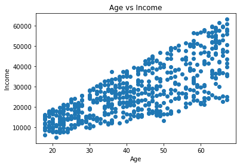

```python
data2 = pd.read_csv("bank_data.csv", index_col=0)
age = data2["age"]
income = data2["income"]

plt.scatter(age, income)
plt.title('Age vs Income')
plt.xlabel('Age')
plt.ylabel('Income')
plt.show()
```

As shown in the above scatter plot, there appears to be a strong, positive correlation between age and income.

## Part 9:

**Create histograms of income and age:**

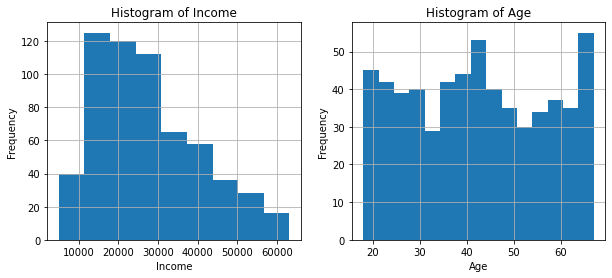

```python
fig = plt.figure(figsize=(10,4))
ax1 = fig.add_subplot(121)
ax1.set_xlabel('Income')
ax1.set_ylabel('Frequency')
ax1.set_title("Histogram of Income")
data2["income"].plot(kind='hist', bins =9, grid=True)

ax1 = fig.add_subplot(122)
ax1.set_xlabel('Age')
ax1.set_ylabel('Frequency')
ax1.set_title("Histogram of Age")
data2["age"].plot(kind='hist', bins =15, grid=True)
```

The above histograms show the distributions of the numerical variables income and age. The histogram of the income variable appears to have a distribution that is postively skewed, albiet closer to a normal distribution than that of the age attribute. From looking at the histogram of income, we can see that the mode income falls somewhere between 10,000 and 20,000. The histogram of the age variable appears to have a mode at, or around the maximum age of 67 years. It does not have a normal distribution. The histogram of income was constructed using 9 bins, while the histogram of age was constructed using 15 bins.

## Part 10:

**Create histogram of region:**

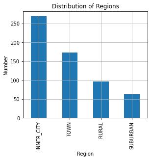

```python
temp = data2["region"].value_counts()

fig = plt.figure(figsize=(10,4))
ax1 = fig.add_subplot(121)
ax1.set_xlabel('Region')
ax1.set_ylabel('Number')
ax1.set_title("Distribution of Regions")
temp.plot(kind='bar', grid = True)
```

The above histogram of the region variable shows the distibution of the four types of places this bank's customers live. The inner city appears to be the most popular region, with around 275 customers living in this region. Towns appears to be the next most popular living area for customers, with approximately 175 customers. Almost 100 of this bank's customers reside in rural areas, and less than 75 of the bank's customers live in suburban areas.

## Part 11:

**Cross-tabulation of region with pep:**

```python
crosstab = pd.crosstab(data2["region"], data2["pep"])
crosstab
```

| pep region | NO | YES |
| --- | --- | --- |
| INNER_CITY | 146 | 123 |
| RURAL | 50 | 46 |
| SUBURBAN | 28 | 34 |
| TOWN | 102 | 71 |

**Plot bar chart of cross-tabulation:**

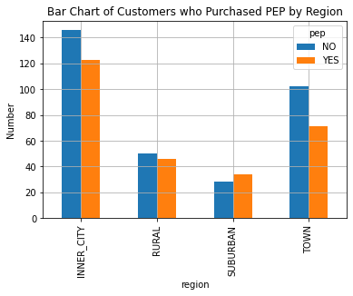

```python
plt.show(crosstab.plot(kind="bar", title = "Bar Chart of Customers who Purchased PEP by Region", ylabel = "Number", grid = True))
```

The above bar chart shows the distibution of this bank's customers by region, and which customers either purchased a PEP, or did not purchase a PEP per region. Looking at this graph, we can see that over 140 of the banks customers who live in the inner city did not purchase a PEP. Alternatively, just over 120 of the inner city customers did purchase a PEP. Of the customers living in rural areas, it appears that around 50 did not purchase a PEP, while a little less than 50 did purchase a PEP. Of the bank's customers who live in suburban areas, almost 30 did not purchase a PEP, while just over 30 customers did purchase a PEP. Of the customers who live in towns, a little more than 100 did not purchase a PEP, while around 70 did purchase a PEP.